# HW2

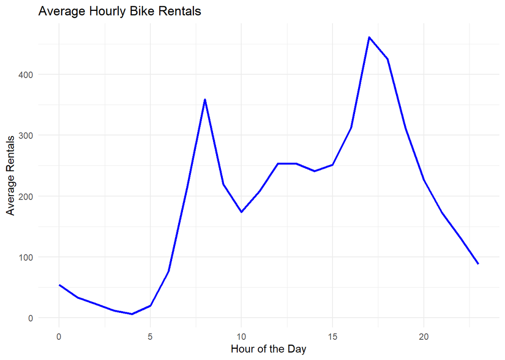

This line graph shows how bike rentals (total) change throughout the day. The x-axis represents the hour of the day (0 to 23), and the y-axis shows the average number of rentals. Rentals peak at 8 AM and 5 PM, which aligns with commuting times.

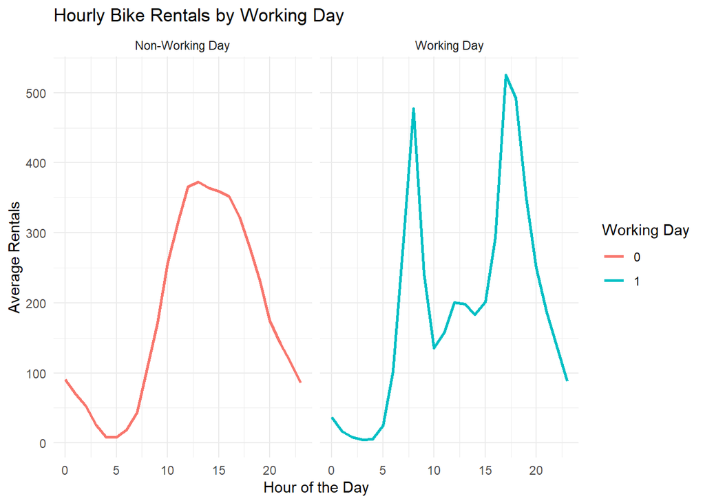

This faceted graph compares bike rentals on working days and non-working days. The x-axis represents the hour of the day, and the y-axis shows the average rentals. On working days, there are noticeable spikes during morning and evening commute hours, whereas non-working days show a steadier rental pattern.

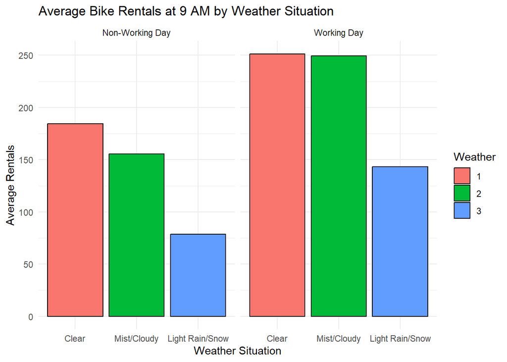

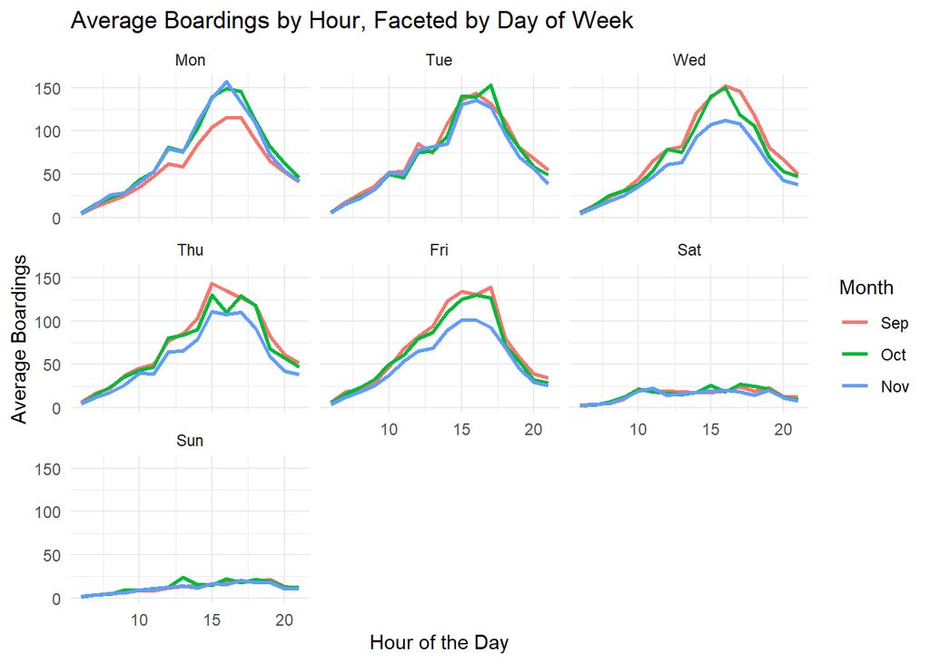

This graph shows how bus boardings (boarding) change throughout the day, with separate panels for each day of the week. The x-axis represents the hour (6 AM to 10 PM), and the y-axis shows the average boardings. Commute times see the highest activity, but Mondays in September and midweek in November see noticeable drops, likely tied to specific events like semester starts and holidays.

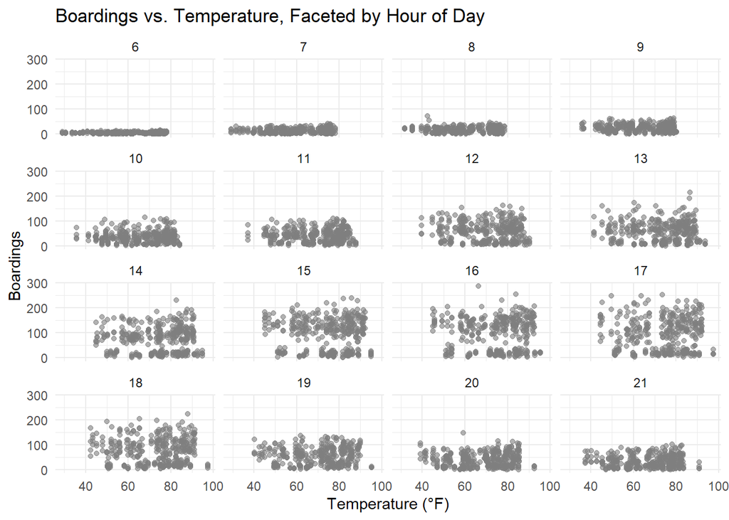

```
## # A tibble: 10 × 3
##    performer                                 song                    total_weeks
##    <chr>                                     <chr>                         <int>
##  1 Imagine Dragons                           Radioactive                      87
##  2 AWOLNATION                                Sail                             79
##  3 Jason Mraz                                I'm Yours                        76
##  4 The Weeknd                                Blinding Lights                  76
##  5 LeAnn Rimes                               How Do I Live                    69
##  6 LMFAO Featuring Lauren Bennett & GoonRock Party Rock Anthem                68
##  7 OneRepublic                               Counting Stars                   68
##  8 Adele                                     Rolling In The Deep              65
##  9 Jewel                                     Foolish Games/You Were…          65
## 10 Carrie Underwood                          Before He Cheats                 64
```

Here’s a table of the top 10 songs based on total weeks on the Billboard Top 100. These tracks clear has the longevity!

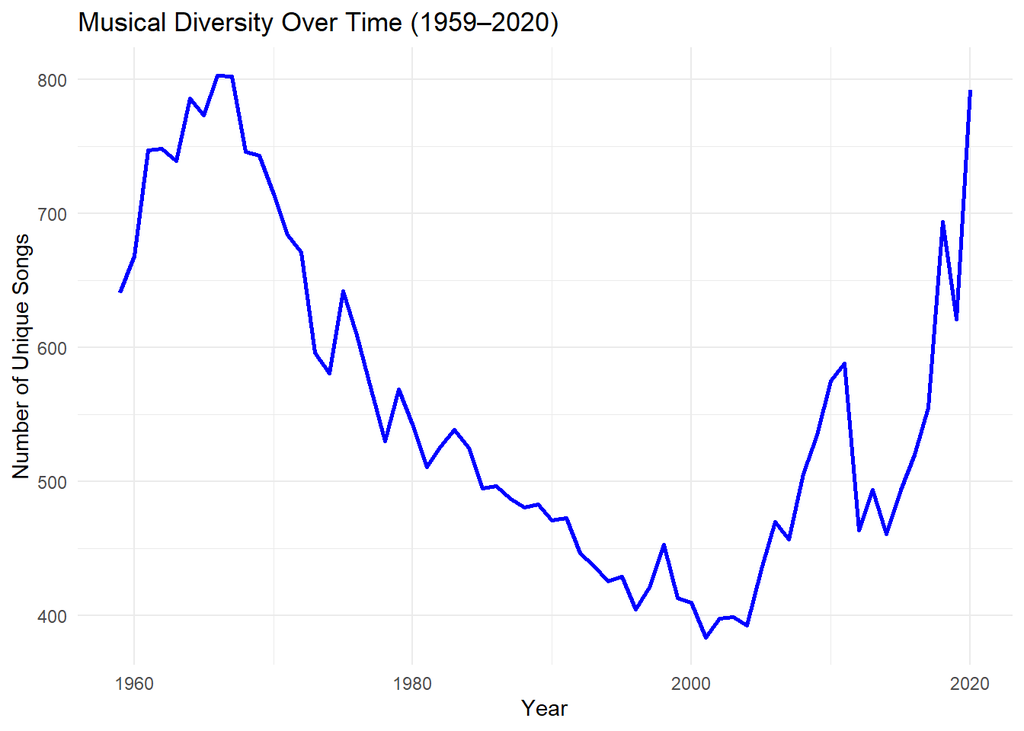

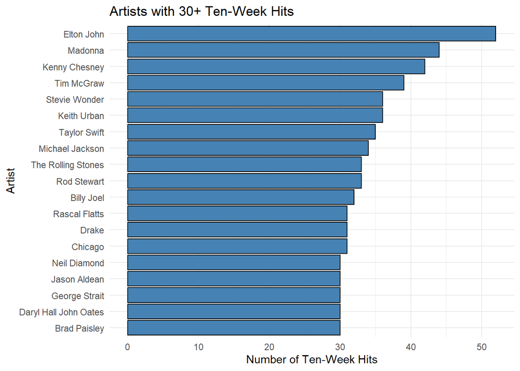